# Analysis of co2 concentration

Coursework1_210373633

18th March 2024

## **1. Introduction**

### **1.1 CO2 Dataset and Purpose of the project**

`co2` is the dataset for atmospheric concentration of carbon dioxide of a Hawaiian volcano, Mauna Loa. Mauna Loa is the largest active volcano located in Southern Hawail. Volcanic activity of the Mauna Loa is considered dangerous due to the lava flowing more freely.

The dataset contains of a total of 468 observations recorded monthly between 1959 and 1997. It is important to note there were 3 missing values during this period: February 1964, March 1964 and April 1964. The values recorded for these months were extracted using linear interpolation.

In this project I will be using multiple packages and functions to help analyse the data recorded about the Hawaiian Volcano. Within the project I will be exploring the linear relation between time and concentration of carbon dioxide and assess the suitability of the model. Further, I will plot the time series graphs to show the general pattern over the 38 years, decompose the time series to analyse the impacts of trend, season and randomness separately as well as plot a HoltWinter graph forecasting the co2 concentration in the following 10 years (from 1997 to 2007). Finally, use Prophet to further forecast and analyse the time series as well as identify anomalies by comparing actual observations with forecasted values (smooth curve).

### **1.2 Packages Used in the project**

In this project I was required to install the following packages to help obtain data as well as help analyse and forecast future values. Astsa is a package that contains countless datasets and scripts to help analyse time series for instance co2. Aside from this I was required to download a package called prophet. Prophet is an inbuilt package which allows us to forecast time series based on models with non-linear models.

## **2. Analysis of data**

### **2.1 Summary of data**

```r
library(astsa)
#imports data
data("co2")

#provides summary of data
summary(CO2)
```

```
##      Plant             Type         Treatment       conc          uptake
##  Qn1    : 7   Quebec     :42   nonchilled:42   Min.   :  95   Min.   : 7.70
##  Qn2    : 7   Mississippi:42   chilled   :42   1st Qu.: 175   1st Qu.:17.90
##  Qn3    : 7                                    Median : 350   Median :28.30
##  Qc1    : 7                                    Mean   : 435   Mean   :27.21
##  Qc3    : 7                                    3rd Qu.: 675   3rd Qu.:37.12
##  Qc2    : 7                                    Max.   :1000   Max.   :45.50
##  (Other):42
```

```r
#computes variance and standard deviation
var(co2)
```

```
## [1] 223.9877
```

```r
sd(co2)
```

```
## [1] 14.96622
```

Var() function in r computes the variance of the sample. This is unbiased and representative of the entire population. The variance value computed above of 223.9877 is relatively high which suggests the atmospheric concentrations is increasing along with time. Further, it suggests atmospheric concentration fluctuate a lot around the mean. This is further, strengthened by the large standard deviation value.

### **2.2 Plot showing Atmospheric Concentration of co2 at Mauna Loa**

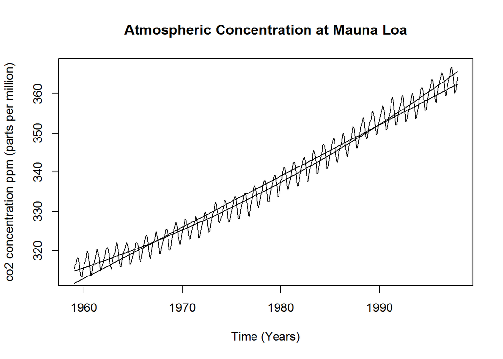

```r
#converts into dataframe
co2_df=data.frame(t=as.vector(time(co2)),x=as.vector(co2))

#plot the data with title and labelled axis
plot(co2_df$t,co2_df$x,xlab="Time (Years)",ylab="co2 concentration ppm (parts per million)",main="Atmospheric Concentration at Mauna Loa",type="l")

#linear regression model
co2_linear=lm(x~t,co2_df)
lines(co2_df$t,fitted(co2_linear),type="l",colors="green")
#quadratic model
co2_quad=lm(x~t+I(t^2),co2_df)
lines(co2_df$t,fitted(co2_quad),type="l",colors="orange")
```

The plot() function shows a visual representation of the `co2` data. Due to the nature of the our data, a line graph is drawn. Graph drawn above contains numerous turning point suggesting the concentration of carbon dioxide in the atmosphere consistently fluctuates whilst gradually increasing over time. Aside from this external factors rapid increase in the use of petrol/diesel cars and a greater usage of flights both contribute to co2 emissions.

Firstly, analysing the linear regression line, it was evident that the trend line did not truly reflect the model. This is because the model drifts further away from the trend line itself suggesting the model doesn’t fit a linear regression.

Concluding, the quadratic regression model proved to present an accurate model for the data provided above.

### **2.3 Time Series Decomposition of co2**

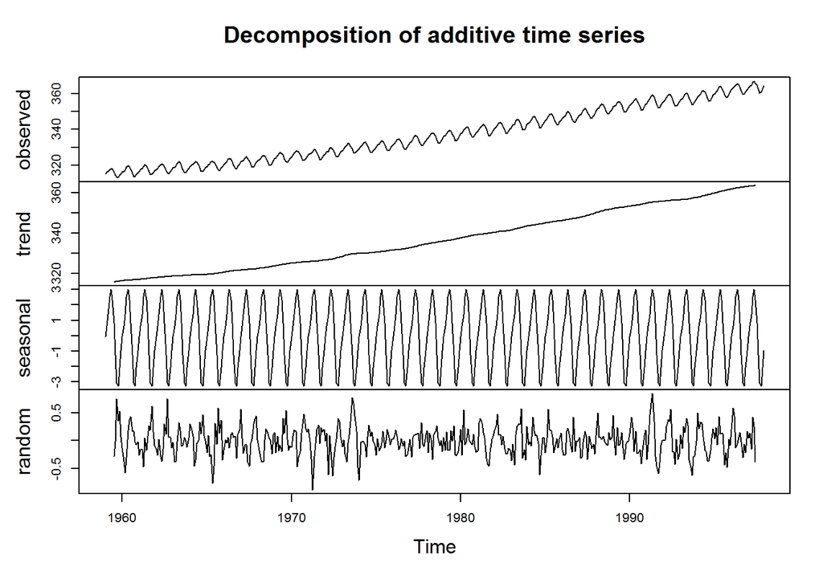

```r
#plots the decomposed time series as 4 distinct graphs representing the different components
plot(decompose(co2))
```

The decomposition function splits the data into 4 components: observed, trend, seasonal, random.

- The first plot is the called Observed plot as it displays the original time series.
- Second plot is called the trend plot as it shows the trend components extracted from the time series. It represents behaviours on long-term basis. The line seems to be relatively steady upward sloping line suggesting the concentration of is gradually increasing with time.
- The seasonal plot is the third plot showing repeated patterns and cycles in the time series. Observing the plot, there is enough evidence to suggest `co2` dataset looks to be centered around 0, with equally raising and falling segments.
- Lastly, the random plot. The random plot represents point that neither belong to the trend component nor the seasonal component - it is the ‘leftovers’ and completely random.

### **2.4 HoltWinters Analysis**

```r
#computes the HoltWinters analysis on the time series data
HoltWinters(co2)
```

```
## Holt-Winters exponential smoothing with trend and additive seasonal component.
##
## Call:
## HoltWinters(x = co2)
##
## Smoothing parameters:
##  alpha: 0.5126484
##  beta : 0.009497669
##  gamma: 0.4728868
##
## Coefficients:
##            [,1]
## a   364.7616237
## b     0.1247438
## s1    0.2215275
## s2    0.9552801
## s3    1.5984744
## s4    2.8758029
## s5    3.2820088
## s6    2.4406990
## s7    0.8969433
## s8   -1.3796428
## s9   -3.4112376
## s10  -3.2570163
## s11  -1.9134850
## s12  -0.5844250
```

HoltWinters is a function in r using techniques for time series forecasting. It analyses both trend and seasonality separately which helps provide accurate forecasts. Further, any unknown parameter is computed by minimising the squared prediction error.

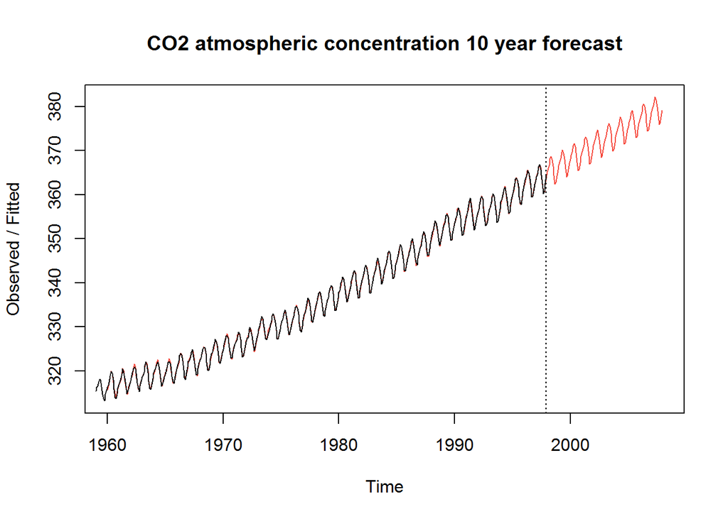

```r
#assigns the HoltWinter analysis to hw
hw=HoltWinters(co2)
#assigns the predicted HoltWinter points to phw
phw=predict(HoltWinters(co2),120)
#plots the graph for the HoltWinters analysis and the predicted values.
#predicted line is represented in red
plot(hw,phw,main="CO2 atmospheric concentration 10 year forecast")
```

Above is a graph that shows the forecasted co2 atmospheric concentration from Mauna Loa for the upcoming 10 years. The line in black represents the original time series data and the red line shows the forecasted period. It is evident there is a positive relation between time and the concentration of co2 in the atmosphere whereby as time increases the level of co2 is also going to increase.

### **2.5 Augmented Dicky-Fuller test**

```r
library(tseries)
tseries::adf.test(co2)
```

```
##
##  Augmented Dickey-Fuller Test
##
## data:  co2
## Dickey-Fuller = -2.8299, Lag order = 7, p-value = 0.2269
## alternative hypothesis: stationary
```

The Augmented Dicky-Fuller test is a one tailed hypothesis test which checks to see whether the time series is stationary or not. we measure the size of the statistic by analysing the p-value. As we are testing to check how stationary the data is out hypothesis are as follows:

- **H0, Null Hypothesis:** time series is not stationary
- **H1, Alternative Hypothesis:** time series is stationary

The p-value obtained for `co2` is 0.2269 which suggests we accept the null hypothesis (H0). This implies that the time series data in `co2` is not stationary. This means that the values recorded in the dataset vary with time.

## **3. Prophet**

### **3.1 Plot for the future values**

```r
#loads prophet
library(prophet)
#convert co2 time series data into a dataframe
co2.df = data.frame(
  ds=zoo::as.yearmon(time(co2)),
  y=co2)

#creates prophet model using the prophet function, assigned to m
m = prophet::prophet(co2.df)
```

```
## Disabling weekly seasonality. Run prophet with weekly.seasonality=TRUE to override this.
```

```
## Disabling daily seasonality. Run prophet with daily.seasonality=TRUE to override this.
```

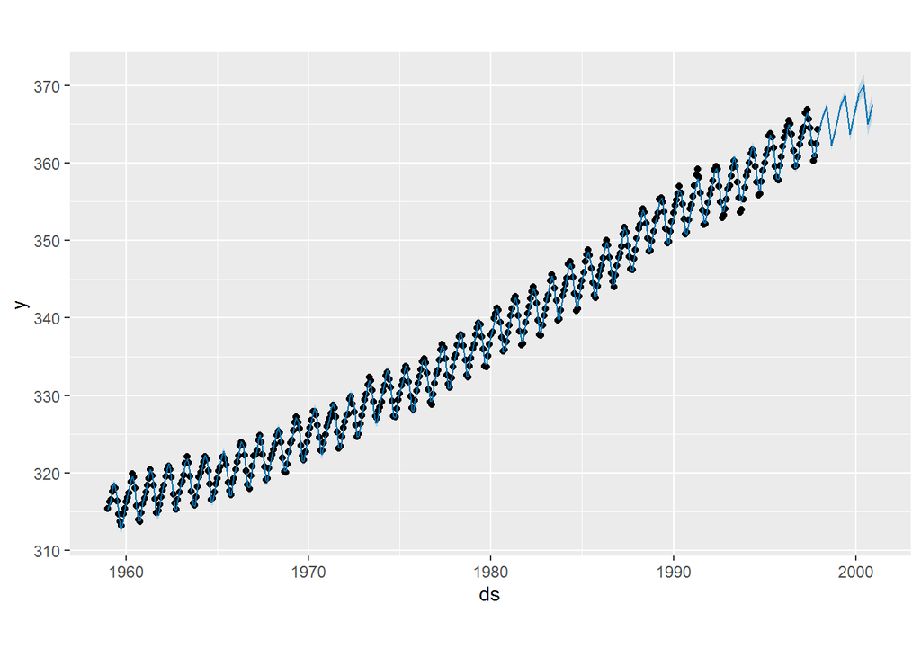

```r
#creates a dataframe with future values
f = prophet::make_future_dataframe(m, periods=12, freq="quarter")

#assigns the predicted values using parameters m and f
p = predict(m, f)

#plots the model and the predicted values
plot(m,p)
```

The Prophet package used above allows me to forecast data values for time series datasets.

Firstly, we create a dataframe, converting the `co2` data. This is essential as Prophet primarily analyses data with dates are stored in one column with corresponding observations in another, in this case the `co2` concentration. We start by extracting the time component from the dataset and converted into a column which incorporates the year and month, the column is labelled ds. Following the we extract the corresponding co2 concentration values are from the dataset and convert it into a column labelled y.

After assigning the prophet model to m, future values to f and the predicted values to p we can graph these. The graph above shows the prophet model of co2 alongside the predicted values.

The graph above shows the prophet model of the co2 dataframe against the predicted future values. The predicted future values are represented by the fluctuating blue time series line.

### **3.2 Exploring co2 dataframe**

```r
#further analysis of the dataframe
co2.df
```

```
##           ds      y
## 1   Jan 1959 315.42
## 2   Feb 1959 316.31
## 3   Mar 1959 316.50
## 4   Apr 1959 317.56
## 5   May 1959 318.13
## 6   Jun 1959 318.00
## 7   Jul 1959 316.39
## 8   Aug 1959 314.65
## 9   Sep 1959 313.68
## 10  Oct 1959 313.18
## 11  Nov 1959 314.66
## 12  Dec 1959 315.43
## 13  Jan 1960 316.27
## 14  Feb 1960 316.81
```

[output cut: 454 more lines]

```r
str(co2.df)
```

```
## 'data.frame':    468 obs. of  2 variables:
##  $ ds: 'yearmon' num  Jan 1959 Feb 1959 Mar 1959 Apr 1959 ...
##  $ y : Time-Series  from 1959 to 1998: 315 316 316 318 318 ...
```

```r
summary(co2.df$y)
```

```
##    Min. 1st Qu.  Median    Mean 3rd Qu.    Max.
##   313.2   323.5   335.2   337.1   350.3   366.8
```

```r
co2.df$ds[which.min(co2.df$y)]
```

```
## [1] "Oct 1959"
```

```r
co2.df$ds[which.max(co2.df$y)]
```

```
## [1] "May 1997"
```

Above we explore `co2` in greater detail analysing the structure and summary. The `co2` dataframe shows there are 2 variables: ds and y. In this scenario ds represents the date in the format of year and month and y represents the time series from 1959 to 1998.

`Summary()` provides a summarised table of the dataframe, highlighting the min/max values, quartile values and the mean. Using $ tells r to analyse the data for a specific variable. This will present the findings for that particular variable. Later using `co.df$ds[which.min()]` provides the corresponding date.

- Minimum value of y is 313.2ppm which corresponds to October 1959
- Maximum value y is 366.8ppm which corresponds to May 1997

These values clearly show the carbon dioxide concentration at the Haiwaiian volcano Mauna Loa is endlessly increasing. This is further supported by the graphs above in Section 3.1 and Section 2.2.